# Decision trees homework

In this homework we will create a decision tree to see which factors are useful in predicting whether or not a passenger on the titanic will survive.

Run the code below before you begin:

```r
library(rpart)
library(rpart.plot)
library(tidyverse)

library(tidyverse)
titanic_set <- read_csv('data/titanic_decision_tree_data.csv')

shuffle_index <- sample(1:nrow(titanic_set))

# shuffle the data so class order isn't in order - need this for training/testing split later on
titanic_set <- titanic_set[shuffle_index, ]
```

**Data Dictionary**

- **sex**: Biological Sex, male or female
- **age_status**: adult or child (child defined as under 16)
- **class** : Ticket class, 1 = 1st (Upper class), 2 = 2nd (Middle Class), 3 = 3rd (Lower Class)
- **port_embarkation**: C = Cherbourg, Q = Queenstown, S = Southampton
- **sibsp** : number of siblings / spouses aboard the Titanic
- **parch**: number of parents / children aboard the Titanic. Some children travelled only with a nanny, therefore parch=0 for them.
- **survived_flag** : did they survive, 0 = No, 1 = Yes

# 1 MVP

## 1.1 Question 1

Cleaning up the data is always the first step. Do the following:

- Take only observations which have a `survived` flag (i.e. that aren’t missing)
- Turn your important variables into factors (sex, survived, pclass, embarkation)
- Create an `age_status` variable which groups individuals under (and including) 16 years of age into a category called “child” category and those over 16 into a category called “adult”.
- Drop the NA
- Drop any variables you don’t need (`X1`, `passenger_id`, `name`, `ticket`, `far`, `cabin`)

If you need help doing this, the code is below, but please try it yourself first so you can learn!

**Data Cleaning Code**

```r
titanic_clean <- titanic_set %>%
  filter(survived %in% c(0,1)) %>%
# Convert to factor level
    mutate(sex = as.factor(sex),
           age_status = as.factor(if_else(age <= 16, "child", "adult")),
         class = factor(pclass, levels = c(3,2,1), labels = c("Lower", "Middle", "Upper")),
           survived_flag = factor(survived, levels = c(0,1), labels = c("No", "Yes")),
           port_embarkation = as.factor(embarked)) %>%
  select(sex, age_status, class, port_embarkation, sib_sp, parch, survived_flag) %>%
  na.omit()
```

## 1.2 Question 2

Have a look at your data and create some plots to ensure you know what you’re working with before you begin. Write a summary of what you have found in your plots. Which variables do you think might be useful to predict whether or not people are going to die? Knowing this before you start is the best way to have a sanity check that your model is doing a good job.

```r
titanic_clean
```

| sex | age_status | class | port_embarkation | sib_sp | parch | survived_flag |
| --- | --- | --- | --- | --- | --- | --- |
| male | adult | Lower | C | 0 | 0 | Yes |
| female | adult | Middle | S | 0 | 0 | Yes |
| female | child | Lower | C | 1 | 0 | No |
| female | child | Middle | S | 0 | 2 | Yes |
| female | adult | Lower | S | 0 | 0 | No |
| male | adult | Upper | S | 0 | 0 | Yes |
| male | child | Lower | S | 0 | 0 | Yes |
| male | adult | Upper | S | 0 | 0 | No |
| female | child | Lower | S | 4 | 2 | No |
| female | adult | Upper | C | 0 | 0 | Yes |

[output cut: 702 more lines]

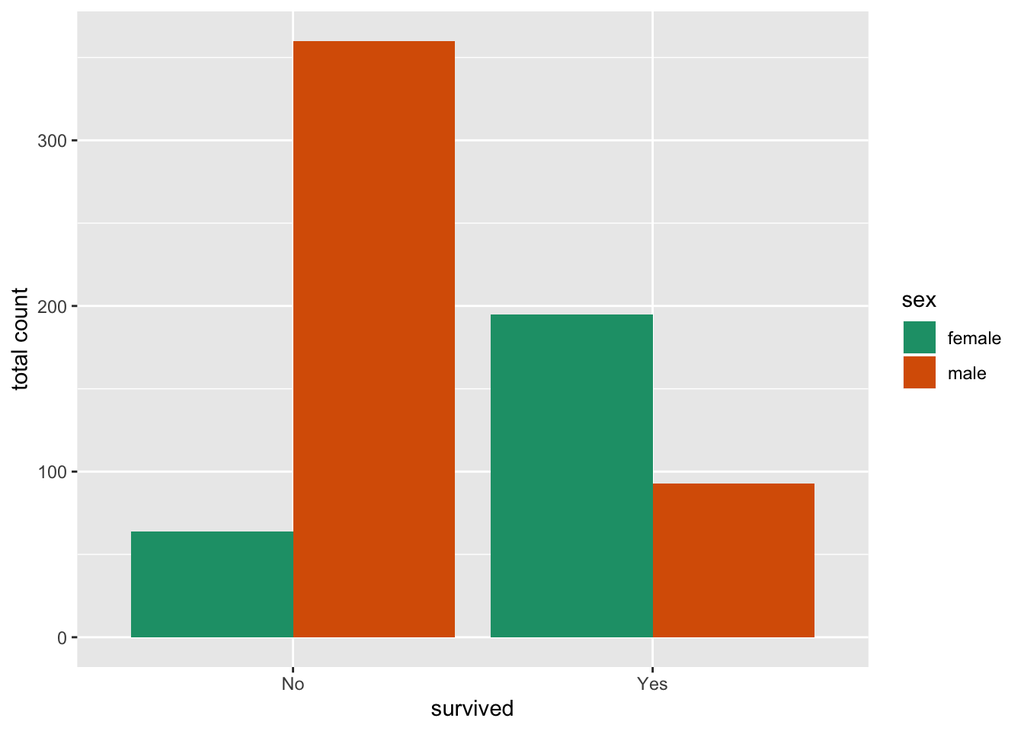

```r
# check the effect of sex
titanic_clean %>%
  select(survived_flag, sex) %>%
  group_by(survived_flag,sex) %>%
  summarise(total_count = n()) %>%
ggplot() +
  aes(x = survived_flag, y = total_count, fill = sex) +
  geom_bar(stat = "identity", position = position_dodge()) +
  scale_fill_brewer(palette="Dark2") +
  ylab("total count") + xlab("survived")
```

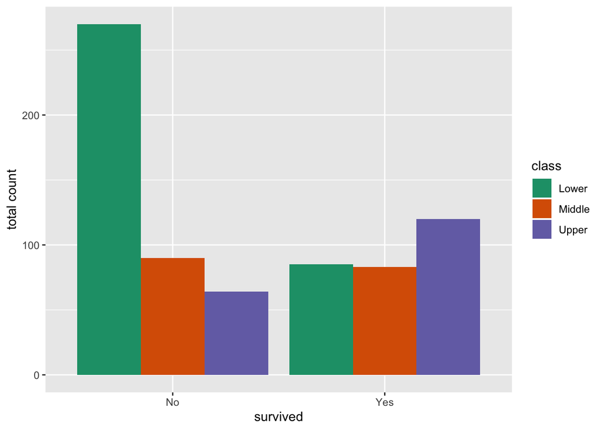

```r
titanic_clean %>%
  select(survived_flag, class) %>%
  group_by(survived_flag,class) %>%
  summarise(total_count = n()) %>%
ggplot() +
  aes(x = survived_flag, y = total_count, fill = class) +
  geom_bar(stat = "identity", position = position_dodge()) +
  scale_fill_brewer(palette="Dark2") +
  ylab("total count") + xlab("survived")
```

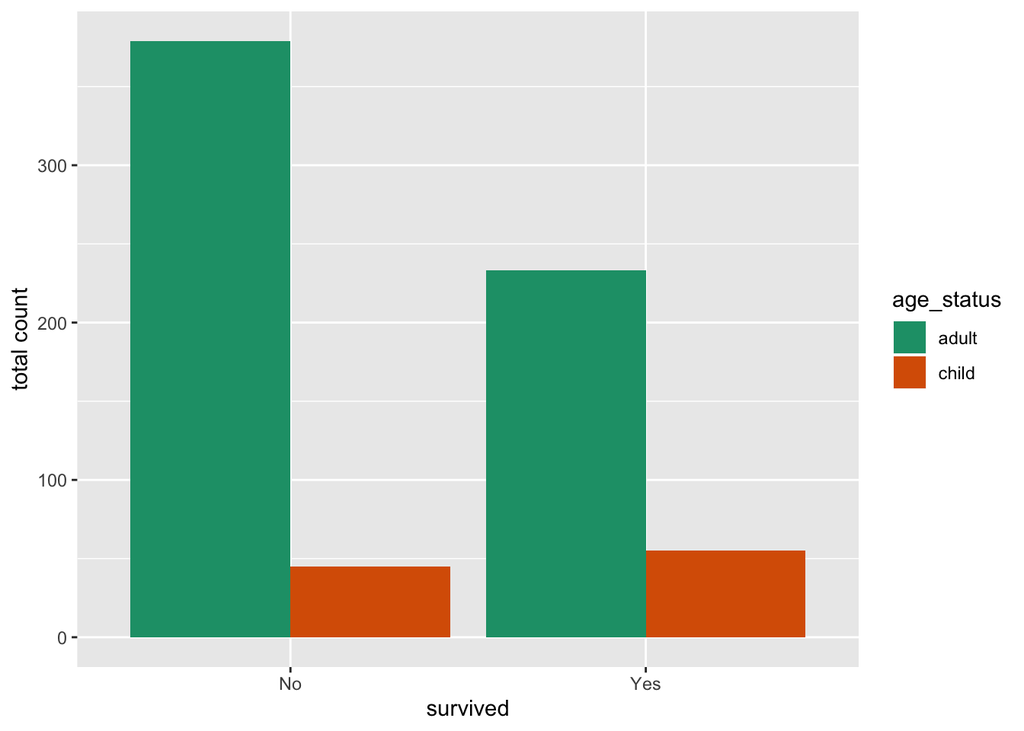

```r
titanic_clean %>%
  select(survived_flag, age_status) %>%
  group_by(survived_flag,age_status) %>%
  summarise(total_count = n()) %>%
ggplot() +
  aes(x = survived_flag, y = total_count, fill = age_status) +
  geom_bar(stat = "identity", position = position_dodge()) +
  scale_fill_brewer(palette="Dark2") +
  ylab("total count") + xlab("survived")
```

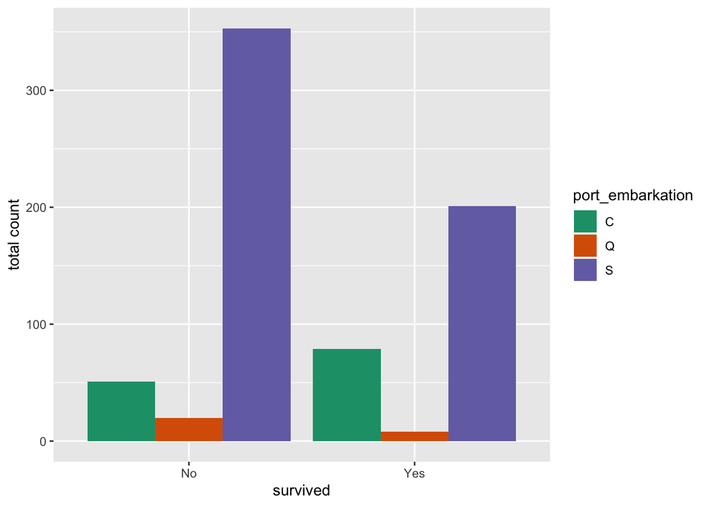

```r
titanic_clean %>%
  select(survived_flag, port_embarkation) %>%
  group_by(survived_flag,port_embarkation) %>%
  summarise(total_count = n()) %>%
ggplot() +
  aes(x = survived_flag, y = total_count, fill = port_embarkation) +
  geom_bar(stat = "identity", position = position_dodge()) +
  scale_fill_brewer(palette="Dark2") +
  ylab("total count") + xlab("survived")
```

My explorations tell me that probably sex, class, age, and port embarkation are going to be useful in predicting whether or not someone will survive because there seems to be differences between these.

## 1.3 Question 3

Now you can start to build your model. Create your testing and training set using an appropriate split. Check you have balanced sets. Write down why you chose the split you did and produce output tables to show whether or not it is balanced.

```r
# set the random seed number: ONLY INSTRUCTORS - students SHOULD NOT do this in their homework
set.seed(3)

n_data <- nrow(titanic_clean)

# create a test sample index
test_index <- sample(1:n_data, size = n_data*0.2)

# create test set
titanic_test  <- slice(titanic_clean, test_index)

# create training set
titanic_train <- slice(titanic_clean, -test_index)

# check balanced sets
titanic_test %>%
 janitor::tabyl(survived_flag)
```

| survived_flag | n | percent |
| --- | --- | --- |
| No | 86 | 0.6056338 |
| Yes | 56 | 0.3943662 |

```r
titanic_train %>%
  janitor::tabyl(survived_flag)
```

| survived_flag | n | percent |
| --- | --- | --- |
| No | 338 | 0.5929825 |
| Yes | 232 | 0.4070175 |

## 1.4 Question 4

Create your decision tree to try and predict survival probability using an appropriate method, and create a decision tree plot.

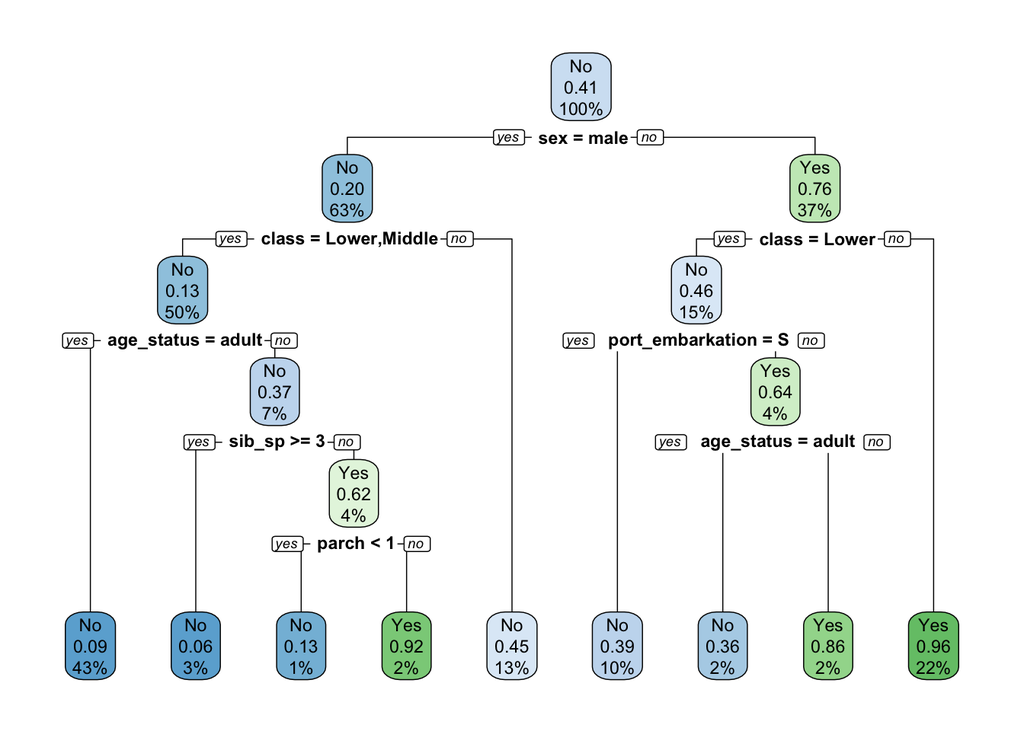

```r
titanic_fit <- rpart(survived_flag ~ .,
                     data = titanic_train,
                     method = 'class')

rpart.plot(titanic_fit, yesno = 2)
```

## 1.5 Question 5

Write down what this tells you, in detail. What variables are important? What does each node tell you? Who has the highest chance of surviving? Who has the lowest? Provide as much detail as you can.

## 1.6 Question 6

Test and add your predicitons to your data. Create a confusion matrix. Write down in detial what this tells you for this specific dataset.

```r
library(modelr)
library(yardstick)
# add the predictions
titanic_test_pred <- titanic_test %>%
                 add_predictions(titanic_fit, type = 'class')


conf_mat <- titanic_test_pred %>%
              conf_mat(truth = survived_flag, estimate = pred)

conf_mat
```

```
##           Truth
## Prediction No Yes
##        No  80  26
##        Yes  6  30
```

# 2 Extension

Decision tree algorithms have various parameters that control aspects of the fit. Adjusting the parameters of a model is called “tuning” and it is a key part of more extensive model building and maintenance. In the `rpart` library, you can control the parameters using the `rpart.control()` function. Refer to the vignette for parameters you can control (e.g. depth, minimum number of sample points a node needs to have, minimum number of samples a leaf node must have). See if you can try to tune the parameters and see if you can improve the model over the default value.

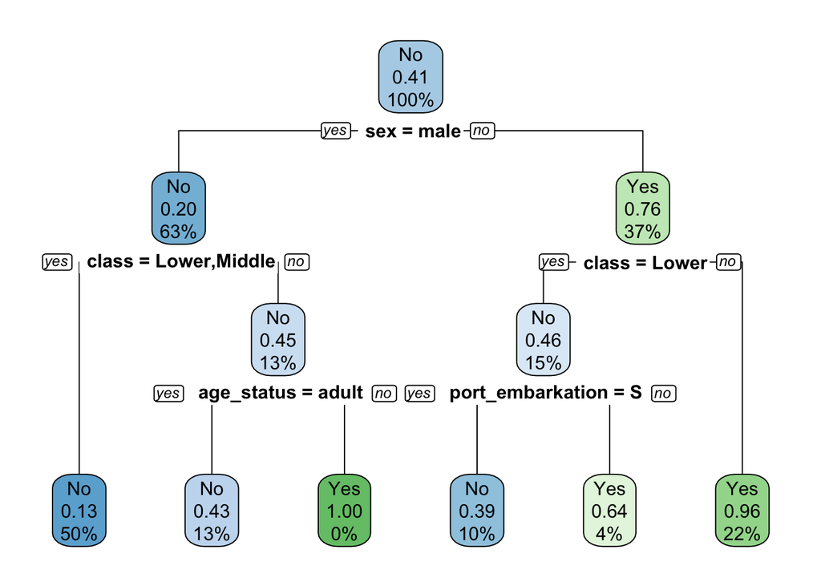

```r
control <- rpart.control(minsplit = 4,
    minbucket = round(5 / 3),
    maxdepth = 3,
    cp = 0)

tune_fit <- rpart(survived_flag ~., data = titanic_train, method = 'class', control = control)

rpart.plot(tune_fit, yesno = 2)
```